# Probing Cooper pair momentum by quasiparticle steering with planar Josephson junctions

**Isidora Araya Day**, Kostas Vilkelis, Antonio Manesco, Mert Bozkurt, Valla Fatemi, Anton Akhmerov

Condensed-matter seminar, University of Basel · 2 November 2026

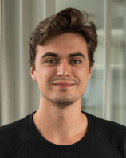

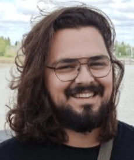

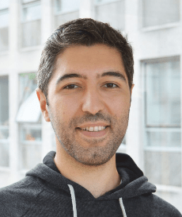

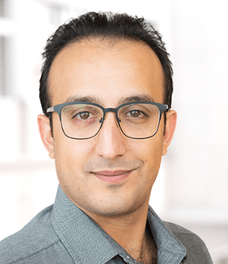

[**arxiv:2607.08845**](https://arxiv.org/pdf/2607.08845)

[**SciPost Phys. 18, 098 (2025)**](https://scipost.org/SciPostPhys.18.3.098/pdf)

# Josephson junctions are versatile building blocks

**Transmons**

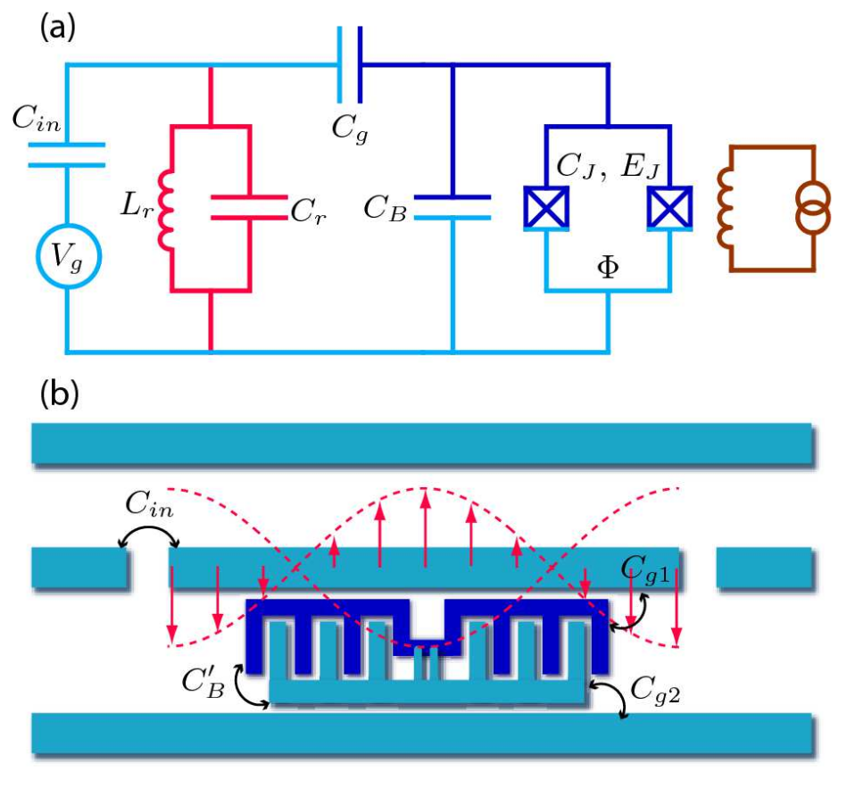

[Koch et al. (2007)](https://doi.org/10.1103/PhysRevA.76.042319)

**Gatemons**

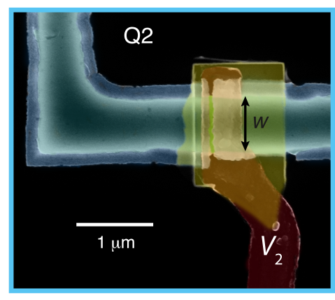

[Casparis et al. (2018)](https://doi.org/10.1038/s41565-018-0207-y)

**Majorana junctions**

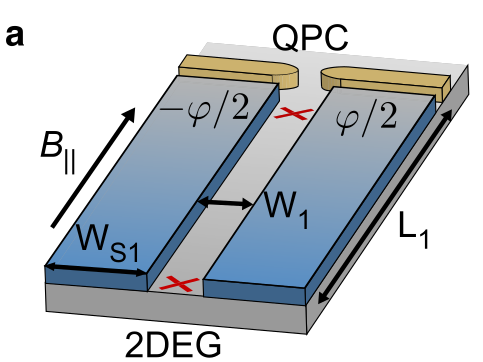

[Fornieri et al. (2019)](https://doi.org/10.1038/s41586-019-1068-8)

We can design **tunnel and SNS junctions in different shapes**, tune **phase and chemical potential**, and apply **magnetic fields**.

# A key advance: epitaxial Al on semiconductors

**Atomic-scale interface**

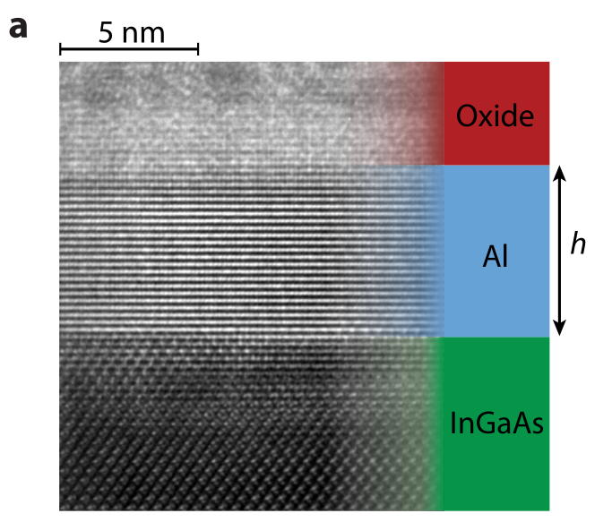

[Shabani et al., **PRB 93, 155402 (2016)**, Fig. 3(a)](https://arxiv.org/abs/1511.01127)

**Patterned planar junction**

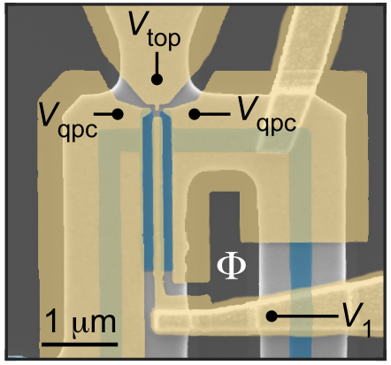

[Fornieri et al., **Nature 569, 89 (2019)**, Fig. 1(c)](https://arxiv.org/abs/1809.03037)

Clean Al (\xi up to 1600 nm), a high-mobility InAs 2DEG, and transparent coupling.

# From the material stack to a planar junction

[figure not shown]

H_{\mathrm{BdG}}= \begin{pmatrix} \dfrac{\hbar^2 k^2}{2m}-\mu & \Delta(y)\,e^{i\phi(y)} \\[6pt] \Delta(y)\,e^{-i\phi(y)} & \mu-\dfrac{\hbar^2 k^2}{2m} \end{pmatrix}

# A numerical curiosity: no splitting

[figure not shown]

We simulated a three-way Josephson junction.

**Two exits are available.**

How does the current divide?

**Numerics: an entire energy window**

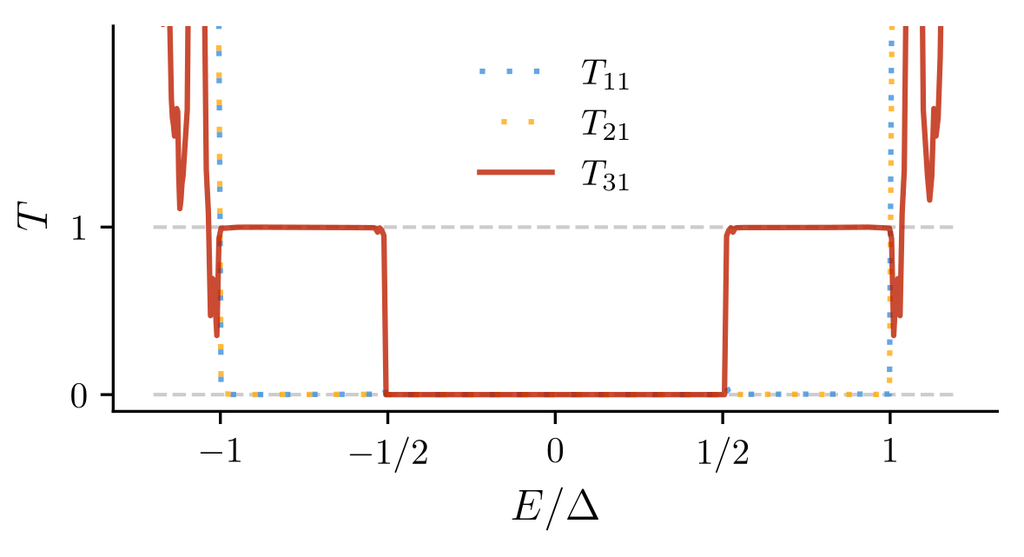

T_{31}=1,\qquad T_{21}=T_{11}=0

SciPost Phys. 18, 098 (2025)

# Quantization can be protected in two ways

**Transmission protected by a smooth potential**

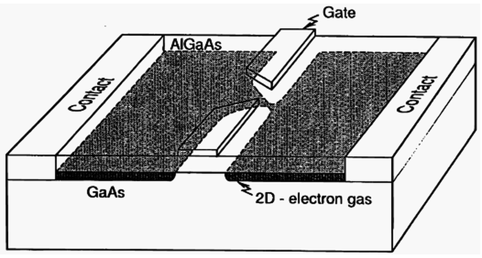

G=N\,\frac{2e^{2}}{h}

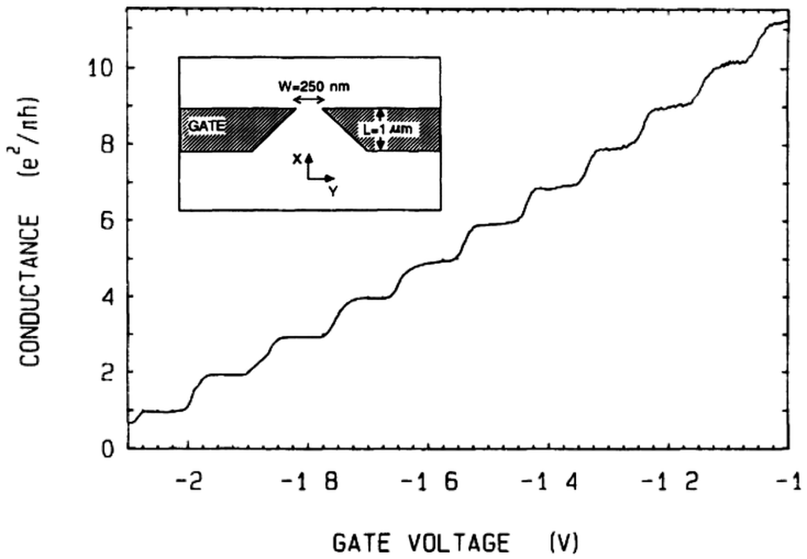

[van Wees et al. (1988)](https://doi.org/10.1103/PhysRevLett.60.848)

**Chiral transmission protected by topology**

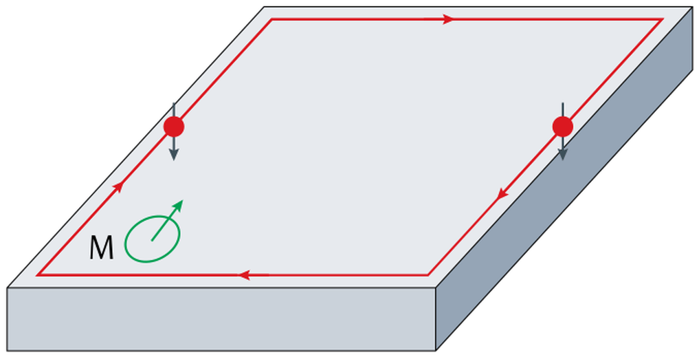

\sigma_{xy}=-\frac{e^{2}}{2\pi\hbar}\,C

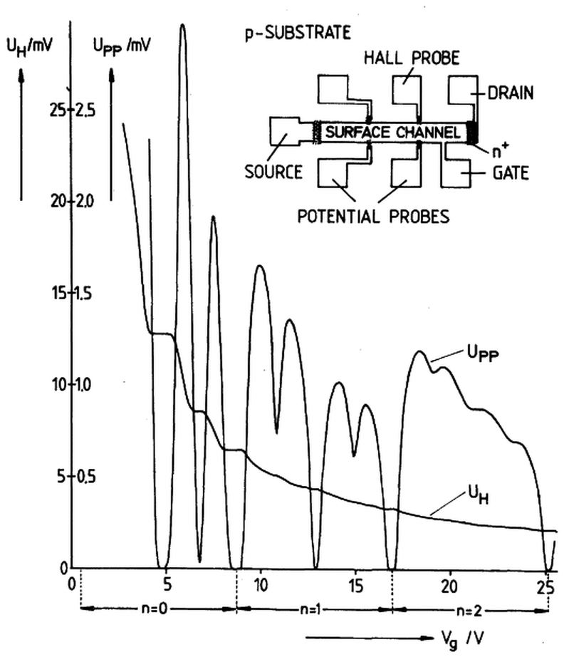

[von Klitzing et al. (1980)](https://doi.org/10.1103/PhysRevLett.45.494)

# Start from one Josephson junction

[figure not shown]

Short (W \ll \xi), transparent junction: E = \pm\Delta\cos(\varphi/2)

Beenakker, **PRL 67, 3836 (1991)**

# Extend it along the interface

[figure not shown]

Andreev approximation: \mu \gg \Delta

# Beyond the Andreev approximation: dispersion

[figure not shown]

Tam & Kane 2023

# The phase difference sets the window

[figure not shown]

Propagating modes for \Delta\cos(\varphi/2) < |E| < \Delta

Tam & Kane 2023

# Three waveguides meet

[figure not shown]

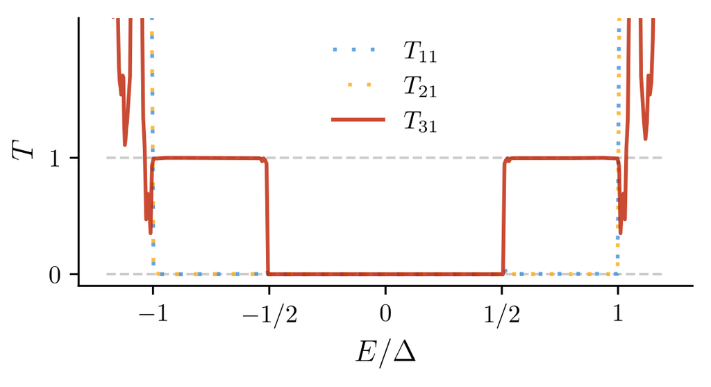

Transmission from arm 1, all phase differences 2\pi/3

SciPost Phys. 18, 098 (2025)

# What do we have so far?

[figure not shown]

**Observations**

1. Quantized transmission between channels
2. Phase sets the available modes
3. Chirality of transmission set by phases

**Requirements**

1. Transparent Josephson junctions
2. Short junction regime, W \ll \xi
3. Metal and superconductor share the same normal Hamiltonian

SciPost Phys. 18, 098 (2025)

# How general is the phenomenon?

[figure not shown]

SciPost Phys. 18, 098 (2025)

# Antonio’s question

[figure not shown]

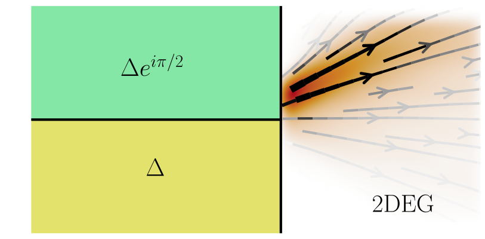

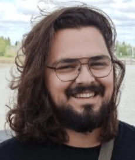

Antonio Manesco

What if the guide simply ends?

Do the modes eject at an angle?

Surprisingly, yes!

Anton Akhmerov

Shouldn’t the angle be tiny, \propto\Delta/\mu?

\mathbf q=\nabla\varphi\quad\text{(Cooper pairs: }\mathbf k,\,-\mathbf k+\mathbf q\text{)}

q\lesssim\xi^{-1}=\frac{\Delta}{\hbar v_F},\quad k_F=\frac{2\mu}{\hbar v_F} \;\Longrightarrow\;\frac{q}{k_F}\lesssim\frac{\Delta}{\mu}

A single Andreev reflection transfers \hbar q.

**arxiv:2607.08845**

# The Hamiltonian sets a square-root scale

**1. Effective Hamiltonian**

near k_x=k_F: linear in \delta k_x, quadratic in k_y

H_{\mathrm{eff}}=[a k_y^2+\hbar v_F\delta k_x]\tau_z+\Delta\left[\cos\tfrac{\varphi}{2}\,\tau_x+\sin\tfrac{\varphi}{2}\,\mathrm{sgn}(y)\,\tau_y\right]

**2. Rescale by the gap**

the only length is \sqrt{a/\Delta}

\kappa_y=k_y\sqrt{a/\Delta},\quad \kappa_x=\frac{\hbar v_F\delta k_x}{\Delta}

\frac{H_{\mathrm{eff}}}{\Delta}=(\kappa_y^2+\kappa_x)\tau_z+\cos\tfrac{\varphi}{2}\,\tau_x+\sin\tfrac{\varphi}{2}\,\mathrm{sgn}(y)\,\tau_y

no small parameter left: \kappa_y depends only on E/\Delta and \varphi

**3. Compare with k_F**

this is the scale of k_y

k_y\sim\sqrt{\Delta/a},\quad k_F=\sqrt{\mu/a} \;\Longrightarrow\; \frac{k_y}{k_F}\sim\sqrt{\Delta/\mu}\;\gg\;\frac{\Delta}{\mu}

This sets the available scale. The phase determines the mean tilt.

**arxiv:2607.08845**

# An unfinished calculation from my PhD

[figure not shown]

First solve the **straight SNS guide**.

**Solve in each superconducting half-plane**

\Phi(y)=\begin{pmatrix}u\\v\end{pmatrix}e^{ik_y y},

\begin{pmatrix} a k_y^2+\hbar v_F\delta k_x-E & \Delta e^{\mp i\varphi/2}\\ \Delta e^{\pm i\varphi/2} & -a k_y^2-\hbar v_F\delta k_x-E \end{pmatrix} \begin{pmatrix}u\\v\end{pmatrix}=0

a k_y^2+\hbar v_F\delta k_x =\pm i\sqrt{\Delta^2-E^2}

Choose roots that remain bounded.

**Match the two halves at y=0**

\Phi_>(0)=\Phi_<(0)

\partial_y\Phi_>(0)=\partial_y\Phi_<(0)

**Incoming ABS**: confined in y, propagating in x.

**Evanescent continuum**: decays as x\to-\infty.

**arxiv:2607.08845**

# Match the guide to the normal region

[figure not shown]

Match the wavefunction at x=0, **for every y**.

**One incoming mode is not enough**

\begin{aligned} \Psi_{\mathrm{SNS}}(0,y)={}&\Phi^{\mathrm{ABS}}(y)\\ &+\int_0^\infty dk\,\big[A_e(k)\Phi^{k,1}(y)\\ &\hspace{52pt}+B_e(k)\Phi^{k,2}(y)\big] \end{aligned}

A continuum of evanescent modes adjusts the field at the open end.

**Match to outgoing electrons**

\psi_h^{\mathrm{SNS}}(0,y)=0,\qquad\psi_e^{\mathrm{SNS}}(0,y)=t(y)

**arxiv:2607.08845**

# Two coupled integral equations

[figure not shown]

Match the wavefunction at x=0, **for every y**.

Anton Akhmerov

Can an agent fix and finish the work?

Solve for A_e(k),B_e(k):

\int_0^\infty dk\, \begin{pmatrix}K_{ua}&K_{ub}\\K_{la}&K_{lb}\end{pmatrix} \begin{pmatrix}A_e\\B_e\end{pmatrix} =\begin{pmatrix}R_u\\R_l\end{pmatrix}

K_{ua}(s,k)=z e^{ik_e(k)s}+A_+^1(k)e^{iks}+A_-^1(k)e^{-iks}

Then t(y)=\psi_e^{\mathrm{SNS}}(0,y) sets the angle:

\Theta=\arctan\!\Big(\sqrt{\Delta/a}\,\frac{\langle k_y\rangle}{k_F}\Big),\qquad \langle k_y\rangle=\frac{\int dy\,t^*(-i\partial_y)\,t}{\int dy\,|t|^2}

[figure not shown]

**arxiv:2607.08845**

# Final angle scaling

**Continuum + Kwant**

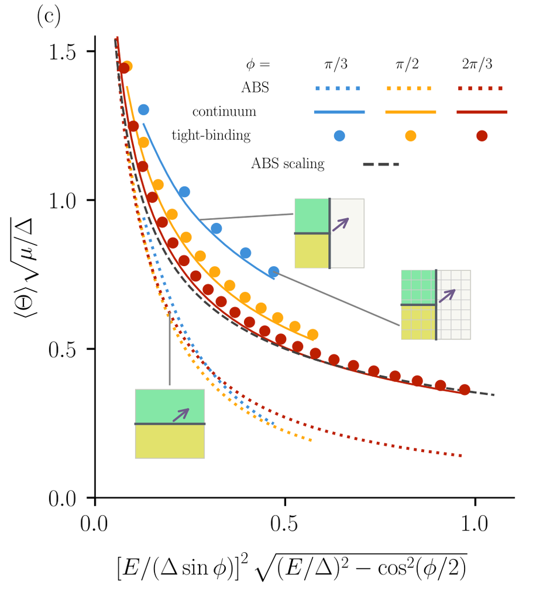

**What we asked Codex to do**

372 requests · 12 conversations

[figure not shown]

**arxiv:2607.08845**

# Summary and outlook

Planar Josephson junctions are waveguides: the Andreev band disperses only beyond the Andreev approximation

Phase winding routes Andreev modes: chiral adiabatic transmission

An open end emits them at a phase-controlled angle of order \sqrt{\Delta/\mu}: the square root amplifies a tiny Cooper pair momentum into a large, measurable angle

**Outlook:** electron optics can read out the emission angle, a magnified kinematic probe of the Cooper pair momentum

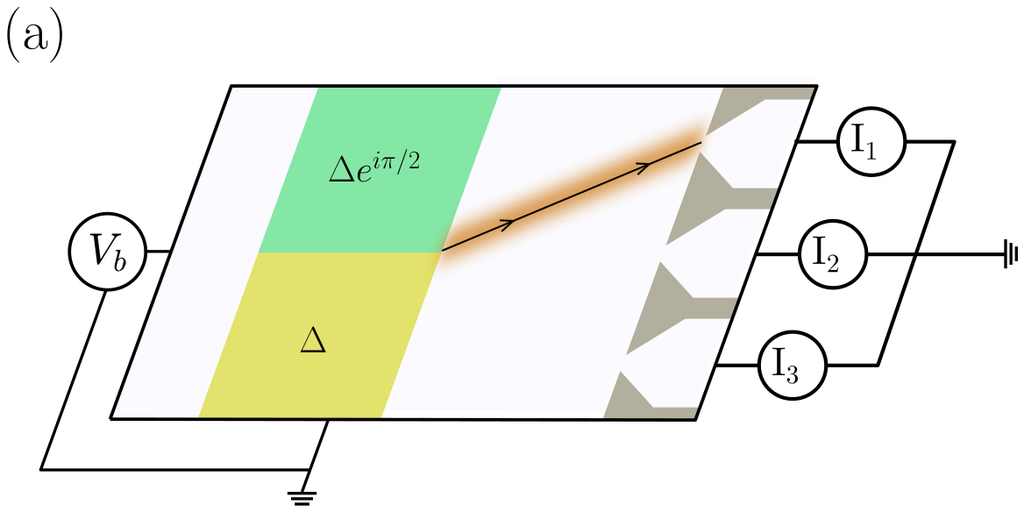

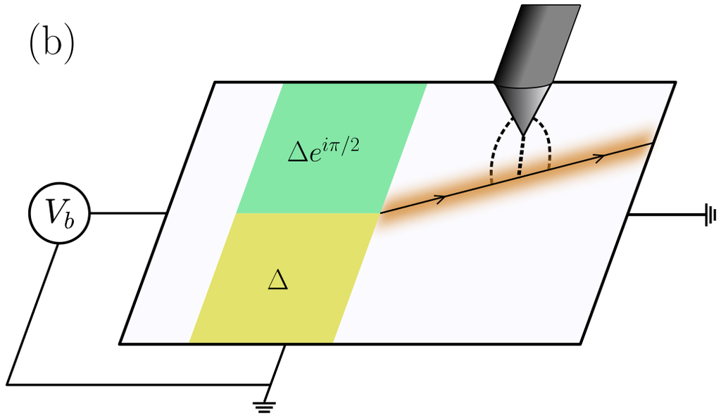

[figure not shown]

**Chiral adiabatic transmission protected by Fermi surface topology**

Araya Day, Vilkelis, Manesco, Bozkurt, Fatemi & Akhmerov

[SciPost Phys. **18**, 098 (2025)](https://scipost.org/SciPostPhys.18.3.098/pdf)

[figure not shown]

**Probing Cooper pair momentum by quasiparticle steering with planar Josephson junctions**

Araya Day, Akhmerov & Manesco

[arXiv:**2607.08845**](https://arxiv.org/pdf/2607.08845)